# Session3: Data wrangling

2025-08-18

## R bootcamp

**“Tidy datasets are all alike, but every messy dataset is messy in its own way.” –– Hadley Wickham**

We will learn about

- Data wrangling with `dplyr`
- Data reshaping with `tidyr`

All with the `diamonds` dataset from `ggplot2` package

## Introduction to `tidyverse`

The `tidyverse` package is a collection of R packages:

- `dplyr`: data manipulation
- `tidyr`: reshaping/tidying data
- `ggplot2`: visualization
- `tibble`: modern rethinking of `data.frame`
- `readr`, `stringr` …

```r
install.packages("tidyverse")
library(tidyverse)
```

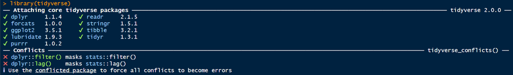

## Brief introduction of `tibble`

- Almost equal to `data.frame`
- **No row names**:
  - `has_rownames()` to check
  - `remove_rownames()` to remove
  - `rownames_to_column()` to add it as a new column
- **Better subsetting**:
  - Always returns a `tibble`
  - no partial matching

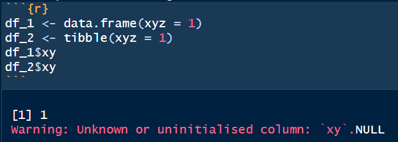

- **Better printing** …

## Example

```r
# A dataset containing the prices and other attributes of ~54000 diamonds
data(diamonds)
head(diamonds)
```

```
## # A tibble: 6 × 10
##   carat cut       color clarity depth table price     x     y     z
##   <dbl> <ord>     <ord> <ord>   <dbl> <dbl> <int> <dbl> <dbl> <dbl>
## 1  0.23 Ideal     E     SI2      61.5    55   326  3.95  3.98  2.43
## 2  0.21 Premium   E     SI1      59.8    61   326  3.89  3.84  2.31
## 3  0.23 Good      E     VS1      56.9    65   327  4.05  4.07  2.31
## 4  0.29 Premium   I     VS2      62.4    58   334  4.2   4.23  2.63
## 5  0.31 Good      J     SI2      63.3    58   335  4.34  4.35  2.75
## 6  0.24 Very Good J     VVS2     62.8    57   336  3.94  3.96  2.48
```

```r
glimpse(diamonds)
```

[output not shown]

## Example

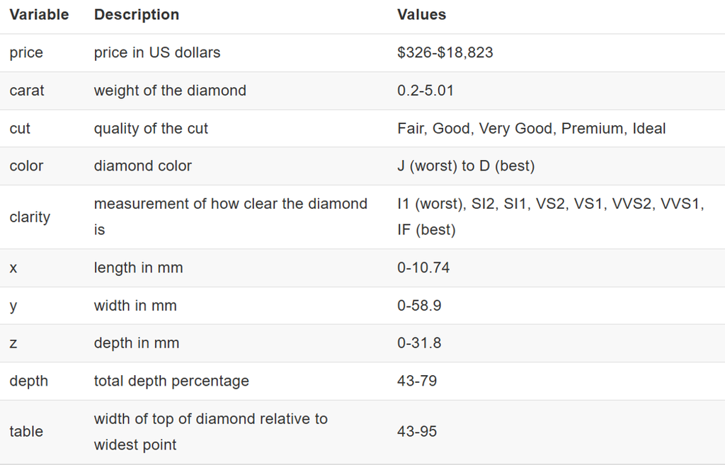

## Example: factor variable

```r
summary(diamonds)
```

```
##      carat               cut        color        clarity          depth
##  Min.   :0.2000   Fair     : 1610   D: 6775   SI1    :13065   Min.   :43.00
##  1st Qu.:0.4000   Good     : 4906   E: 9797   VS2    :12258   1st Qu.:61.00
##  Median :0.7000   Very Good:12082   F: 9542   SI2    : 9194   Median :61.80
##  Mean   :0.7979   Premium  :13791   G:11292   VS1    : 8171   Mean   :61.75
##  3rd Qu.:1.0400   Ideal    :21551   H: 8304   VVS2   : 5066   3rd Qu.:62.50
##  Max.   :5.0100                     I: 5422   VVS1   : 3655   Max.   :79.00
##                                     J: 2808   (Other): 2531
##      table           price             x                y
##  Min.   :43.00   Min.   :  326   Min.   : 0.000   Min.   : 0.000
##  1st Qu.:56.00   1st Qu.:  950   1st Qu.: 4.710   1st Qu.: 4.720
##  Median :57.00   Median : 2401   Median : 5.700   Median : 5.710
##  Mean   :57.46   Mean   : 3933   Mean   : 5.731   Mean   : 5.735
##  3rd Qu.:59.00   3rd Qu.: 5324   3rd Qu.: 6.540   3rd Qu.: 6.540
##  Max.   :95.00   Max.   :18823   Max.   :10.740   Max.   :58.900
##
##        z
##  Min.   : 0.000
##  1st Qu.: 2.910
##  Median : 3.530
##  Mean   : 3.539
##  3rd Qu.: 4.040
##  Max.   :31.800
##
```

## The `dplyr` package

Typically we need to explore and prepare data for analysis:

- create summary statistics for variables and individuals.
- individuals that do not meet certain criteria need to be removed.
- create new variables.
- do multiple things at the same time, eg. subsetting, creating, extracting.

`dplyr` provide a clean and nice syntax to perform these!

## Commonly-used `dplyr` functions

“verb” functions in `dplyr`:

- `select()`
- `filter()`
- `mutate()`
- `summarize()`
- `group_by()`

When multiple packages are loaded, it would be better to add `dplyr::` in front of these functions to avoid function conflicts.

## `select()`: subsetting data column wise

- `select()` allows you to select columns (or variables) in a data frame.
- `select(x, y)` means selecting variable `y` from data frame `x`.
- Note: `y` can be a vector of column names or numerical positions in the data frame.

## `select()`: in action

```r
select(diamonds, carat, price) # extract carat and price
```

```
## # A tibble: 53,940 × 2
##    carat price
##    <dbl> <int>
##  1  0.23   326
##  2  0.21   326
##  3  0.23   327
##  4  0.29   334
##  5  0.31   335
##  6  0.24   336
##  7  0.24   336
##  8  0.26   337
##  9  0.22   337
## 10  0.23   338
## # ℹ 53,930 more rows
```

## `select()`: the 4C’s

Exercise: create a dataframe, `diamonds_4c`, that contains the 4C’s (cut, color, clarity, carat)

```r
diamonds_4c <- ...
```

## `select()`: the 4C’s

```r
diamonds_4c <- select(diamonds, cut, color, clarity, carat)
head(diamonds_4c)
```

```
## # A tibble: 6 × 4
##   cut       color clarity carat
##   <ord>     <ord> <ord>   <dbl>
## 1 Ideal     E     SI2      0.23
## 2 Premium   E     SI1      0.21
## 3 Good      E     VS1      0.23
## 4 Premium   I     VS2      0.29
## 5 Good      J     SI2      0.31
## 6 Very Good J     VVS2     0.24
```

Note that the order of the columns is the same as we specified!

## `select()`: a simpler way to exact columns

When we have hundards or even thousands of columns, it would less efficient to manually select columns

so it would be better if we could select columns based on some conditions:

```r
diamonds_4c <- select(diamonds, starts_with("c"))
head(diamonds_4c)
```

```
## # A tibble: 6 × 4
##   carat cut       color clarity
##   <dbl> <ord>     <ord> <ord>
## 1  0.23 Ideal     E     SI2
## 2  0.21 Premium   E     SI1
## 3  0.23 Good      E     VS1
## 4  0.29 Premium   I     VS2
## 5  0.31 Good      J     SI2
## 6  0.24 Very Good J     VVS2
```

## `select()`: a simpler way to exact columns

More options for `select()`:

- `starts_with()`: Start with a literal string
- `ends_with()`: End with a literal string
- `contains()`: Contains a literal string
- `everything()`: Select all columns

Or select with self-defined condition:

```r
select_if(diamonds, is.numeric)[1, ]
```

```
## # A tibble: 1 × 7
##   carat depth table price     x     y     z
##   <dbl> <dbl> <dbl> <int> <dbl> <dbl> <dbl>
## 1  0.23  61.5    55   326  3.95  3.98  2.43
```

## `select()`: remove columns

Now if we want to remove 4C columns and keep other columns in `diamonds`, usually for `data.frame` would do something like

```r
diamonds$cut <- NULL
...
```

For `select()` it is:

```r
diamonds_r4c <- select(diamonds, -cut, -color, -clarity, -carat)
```

Or even better:

```r
diamonds_r4c <- select(diamonds, -starts_with("c"))
diamonds_r4c[1, ]
```

```
## # A tibble: 1 × 6
##   depth table price     x     y     z
##   <dbl> <dbl> <int> <dbl> <dbl> <dbl>
## 1  61.5    55   326  3.95  3.98  2.43
```

## `filter()`: subsetting data row-wise

- `filter()` allows you to extract rows that meet some logical criteria.
- `filter(x, y)`: extract the rows of `x` where `y` is `TRUE`.

Example:

```r
head(filter(diamonds, price <= 2000)) # filter diamonds with price under 2000
```

```
## # A tibble: 6 × 10
##   carat cut       color clarity depth table price     x     y     z
##   <dbl> <ord>     <ord> <ord>   <dbl> <dbl> <int> <dbl> <dbl> <dbl>
## 1  0.23 Ideal     E     SI2      61.5    55   326  3.95  3.98  2.43
## 2  0.21 Premium   E     SI1      59.8    61   326  3.89  3.84  2.31
## 3  0.23 Good      E     VS1      56.9    65   327  4.05  4.07  2.31
## 4  0.29 Premium   I     VS2      62.4    58   334  4.2   4.23  2.63
## 5  0.31 Good      J     SI2      63.3    58   335  4.34  4.35  2.75
## 6  0.24 Very Good J     VVS2     62.8    57   336  3.94  3.96  2.48
```

## `filter()`: The high roller

Suppose a customer arrives at your store and wants to only look at your “finest” diamonds. Create a data frame `diamonds_fine` that contains all diamonds that are both *ideal* in cut and *internally flawless* (IF) in clarity.

## Exercise: The high roller

```r
diamonds_fine <- filter(diamonds,
                        clarity == "IF" & cut == "Ideal")
diamonds_fine
```

```
## # A tibble: 1,212 × 10
##    carat cut   color clarity depth table price     x     y     z
##    <dbl> <ord> <ord> <ord>   <dbl> <dbl> <int> <dbl> <dbl> <dbl>
##  1  0.52 Ideal F     IF       62.2  55    2783  5.14  5.18  3.21
##  2  0.55 Ideal G     IF       60.9  57    2789  5.28  5.3   3.22
##  3  0.64 Ideal G     IF       61.3  56    2790  5.54  5.58  3.41
##  4  0.61 Ideal G     IF       62.3  56    2800  5.43  5.45  3.39
##  5  0.53 Ideal F     IF       61.9  54    2802  5.22  5.25  3.24
##  6  0.62 Ideal G     IF       60.5  57    2868  5.52  5.56  3.35
##  7  0.62 Ideal G     IF       61.8  56    2869  5.43  5.47  3.37
##  8  0.71 Ideal I     IF       61.5  56    2925  5.74  5.77  3.54
##  9  0.74 Ideal I     IF       62.1  53.9  2952  5.79  5.81  3.6
## 10  0.64 Ideal G     IF       61.7  58    2960  5.52  5.56  3.42
## # ℹ 1,202 more rows
```